# STA 363 Fall 2024

Take-Home Final Exam Instructions

#### Due: Wednesday, September 18th, at 12 pm

## Rules

1. Your solutions must be written up in a Quarto (qmd) file and then rendered into an HTML file called `exam-02.html`. This file must include your code, output, and write-up for each question. Please use the `head` function when printing any result with over 20 rows.
2. This exam is open-book, open-internet, closed to other people. You may use any online or book-based resource you would like, but you must include citations for any code you use (directly or indirectly). You **may not** consult anyone about this exam other than the Professor. You cannot ask direct questions online, or consult other students even for a hypothetical question.
3. You will be required to upload the HTML file from your output. Technical difficulties are **not** an excuse for late work - do not wait until the last minute. **Verify your HTML file includes all graphs and tables before uploading to Moodle. Use the embedded resources option in the YAML.** If I have you to re-render, and resubmit, you will lose 5 points on the exam. Use the following YAML in your document so images are embedded:

```r
---
title: "GIVE YOUR EXAM A TITLE"
author: "PLACE YOUR NAME"
format:
  html:
    embed-resources: true
    code-fold: true
    code-summary: "Show the code"
---
```

4. Your analysis’, outputs, and narratives, not your code, should answer the questions. I have enabled fold folding so your code will stay collapsed in your rendered documents.
5. The in-class exam is worth `50 points`. The take-home is worth `100 points`.

## Data

A student research team at St. Olaf College contributed to the efforts of biologist Dr. Kathy Shea to investigate a rich data set concerning forestation in the surrounding land. Tubes were placed on trees in some locations or *transects* but not in others. Interest centers on whether tree growth is affected by the presence of tubes. The data is currently stored in long format in `treetube.csv`. Each row represents one tree in a given year. Key variables include:

```
- `id`: id of individual tree
- `transect`: The id of the transect housing the tree
- `tubex`: 1 if the tree had a tube, 0 if not
- `species`: The tree's species
- `year`: year of the observation
- `height`: The tree's height in meters
```

## Questions

1. *Complete an exploratory data analysis.* The code provided should be useful but it is not exhaustive (more may be needed). You do **not** need to replicate any of the included EDA in your script. Please reference the included plots using the figure numbers on the bottom right.
2. *Fit two level models to predict tree height.* Start with an unconditional means model with `species` as your grouping variable. Build more appropriate two level models but make sure to explain your variable choices by using your EDA. `species` should remain as your grouping variable.
3. *Compare the models and choose the best model.* Include a Likelihood Ratio Test using the parametric bootstrap (use the function provided), as well as other metrics.
4. *Assess your final chosen model.* Check model conditions and any use limitations.
5. *Interpret coefficients from your chosen model.* Interpret all fixed effects of variables of your best model using bootstrap confidence intervals. Interpret the estimates of the variance components (no confidence interval is needed).

## Submission

When you are finished with your exam, be sure to Render the final document. Once rendered, you can download your file by:

- Finding the .html file in your File pane (on the bottom right of the screen)
- Click the check box next to the file
- Click the blue gear above and then click “Export” to download
- Submit your final html document to the exam spot on [Moodle](https://moodle.cornellcollege.edu/course/view.php?id=7908)

## Code

### Setup and Function

```r
library(tidyverse)
library(tidymodels)
library(broom.mixed)
library(ggridges)
library(DataExplorer)

bootstrapAnova <- function(mA, m0, B=1000){
  oneBootstrap <- function(m0, mA){
    d <- drop(simulate(m0))
    m2 <-refit(mA, newresp=d)
    m1 <-refit(m0, newresp=d)
    return(anova(m2,m1)$Chisq[2])
  }
  nulldist <- replicate(B, oneBootstrap(m0, mA))
  ret <- anova(mA, m0)
  ret$"Pr(>Chisq)"[2] <- mean(ret$Chisq[2] < nulldist)
  names(ret)[8] <- "Pr_boot(>Chisq)"
  attr(ret, "heading") <- c(attr(ret, "heading")[1],
                            paste("Parametric bootstrap with", B,"samples."),
                            attr(ret, "heading")[-1])
  attr(ret, "nulldist") <- nulldist
  return(ret)
}
```

### Data

```r
treeTubes <- read_csv("data/treetube_exam.csv") |> janitor::clean_names()
```

### EDA Code

```r
introduce(treeTubes)
```

```
# A tibble: 1 × 9
   rows columns discrete_columns continuous_columns all_missing_columns
  <int>   <int>            <int>              <int>               <int>
1  4643       6                1                  5                   0
# ℹ 4 more variables: total_missing_values <int>, complete_rows <int>,
#   total_observations <int>, memory_usage <dbl>
```

```r
glimpse(treeTubes)
```

```
Rows: 4,643
Columns: 6
$ id       <dbl> 147, 869, 338, 1125, 569, 1215, 337, 974, 136, 1875, 1288, 61…
$ transect <dbl> 5, 26, 9, 17, 22, 9, 9, 5, 5, 9, 14, 26, 1, 22, 5, 9, 22, 5, …
$ species  <chr> "Bur Oak", "Red Maple", "Black Walnut", "Sugar Maple", "Black…
$ tubex    <dbl> 0, 0, 0, 1, 0, 0, 0, 0, 0, 0, 0, 0, 0, 0, 0, 0, 0, 0, 0, 0, 0…
$ year     <dbl> 1999, 1999, 1990, 2002, 2002, 1993, 1999, 2006, 1995, 2002, 2…
$ height   <dbl> 1.940, 2.560, 0.235, 1.000, 2.150, 0.846, 1.560, 6.300, 0.363…
```

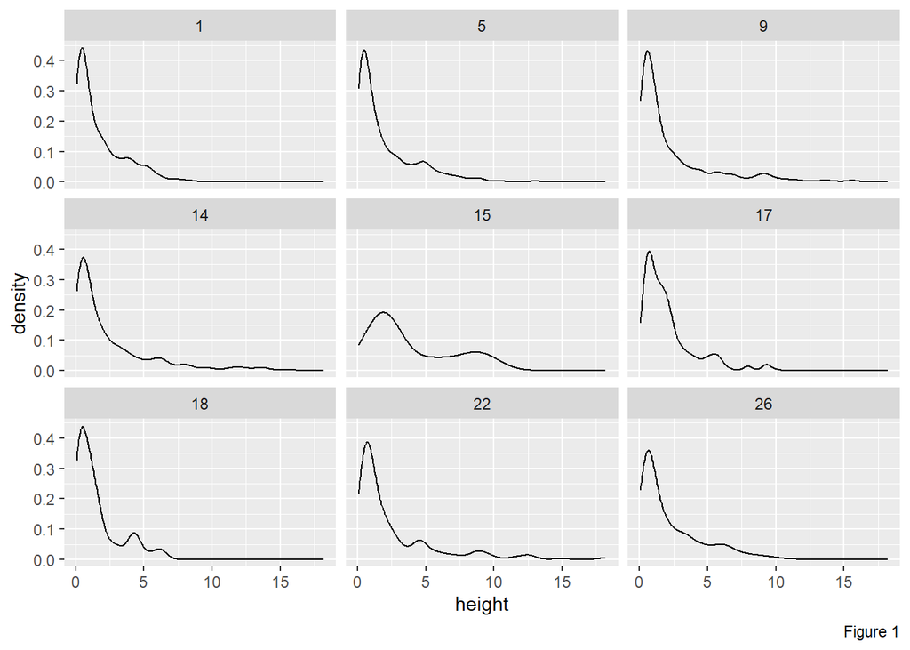

```r
#transect/height
ggplot(treeTubes) +geom_density(aes(x = height)) +
  facet_wrap(~transect)+
  labs(caption = "Figure 1")
```

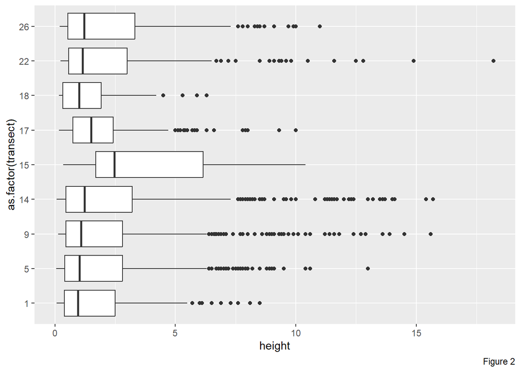

```r
ggplot(treeTubes) +
  geom_boxplot(aes(x = as.factor(transect), y = height)) +
  coord_flip()+
  labs(caption = "Figure 2")
```

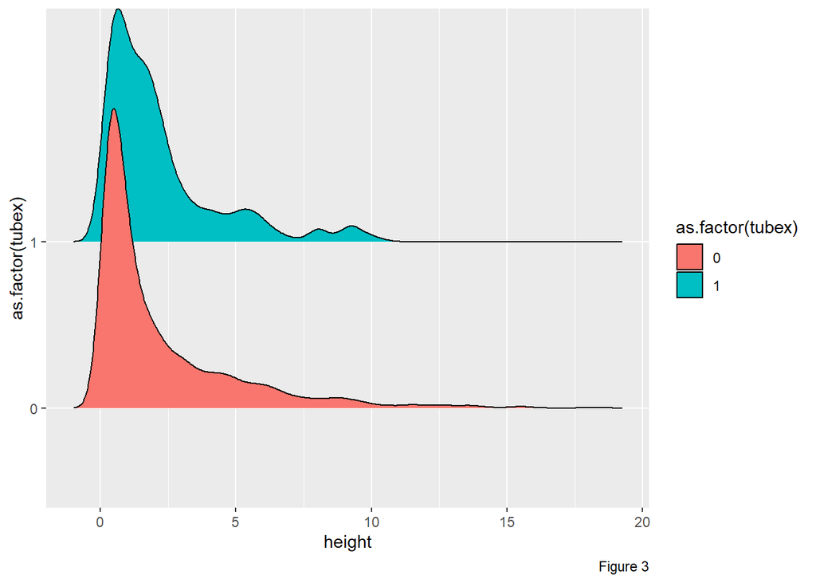

```r
#tubex/height
ggplot(treeTubes) +
  geom_density_ridges(aes(x = height, y = as.factor(tubex),fill=as.factor(tubex)))+
  labs(caption = "Figure 3")
```

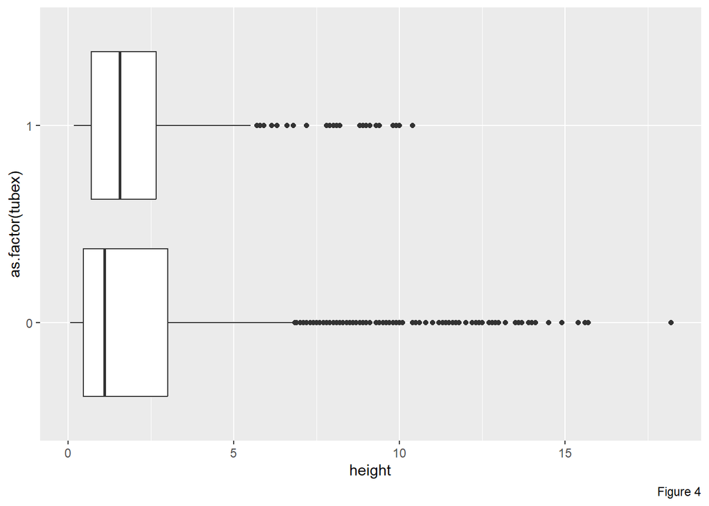

```r
ggplot(treeTubes) +
  geom_boxplot(aes(x = as.factor(tubex), y = height)) +
  coord_flip()+
  labs(caption = "Figure 4")
```

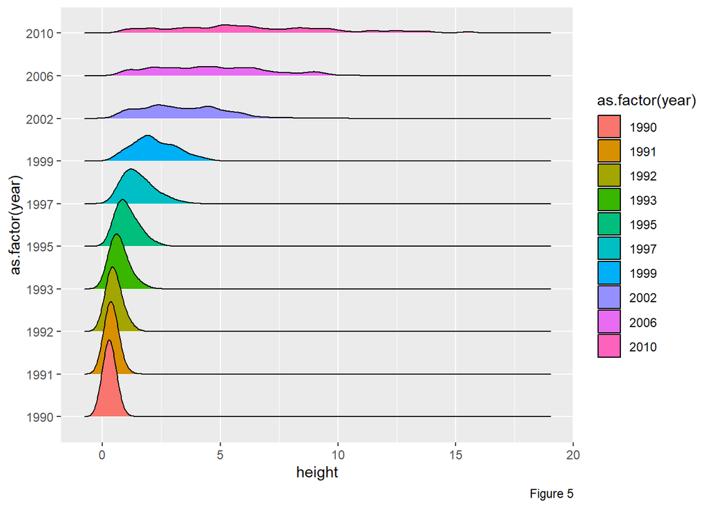

```r
#year/height
ggplot(treeTubes) +
  geom_density_ridges(aes(x = height, y = as.factor(year),fill=as.factor(year)))+
  labs(caption = "Figure 5")
```

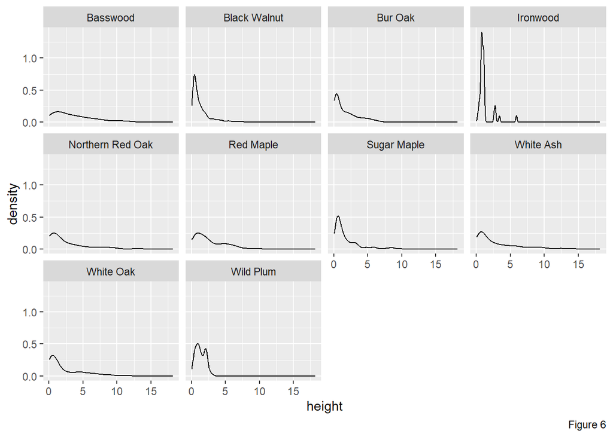

```r
#species/height
ggplot(treeTubes) +
  geom_density(aes(x = height)) +
  facet_wrap(~species)+
  labs(caption = "Figure 6")
```

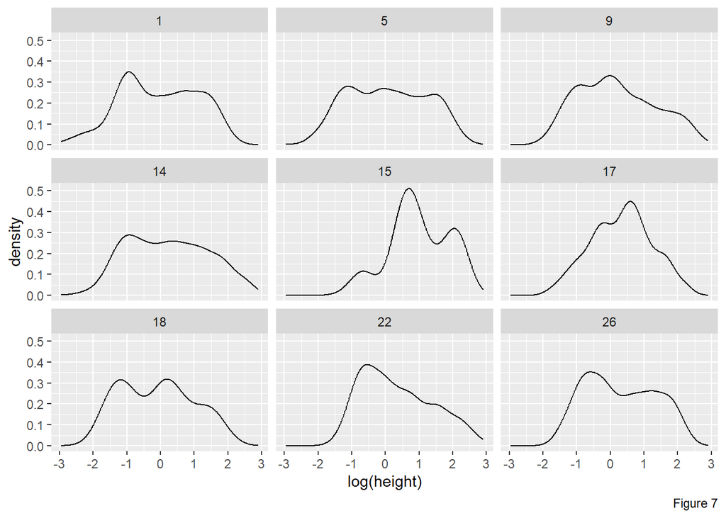

```r
# Repeat all with log height
ggplot(treeTubes) +
  geom_density(aes(x = log(height))) +
  facet_wrap(~transect)+
  labs(caption = "Figure 7")
```

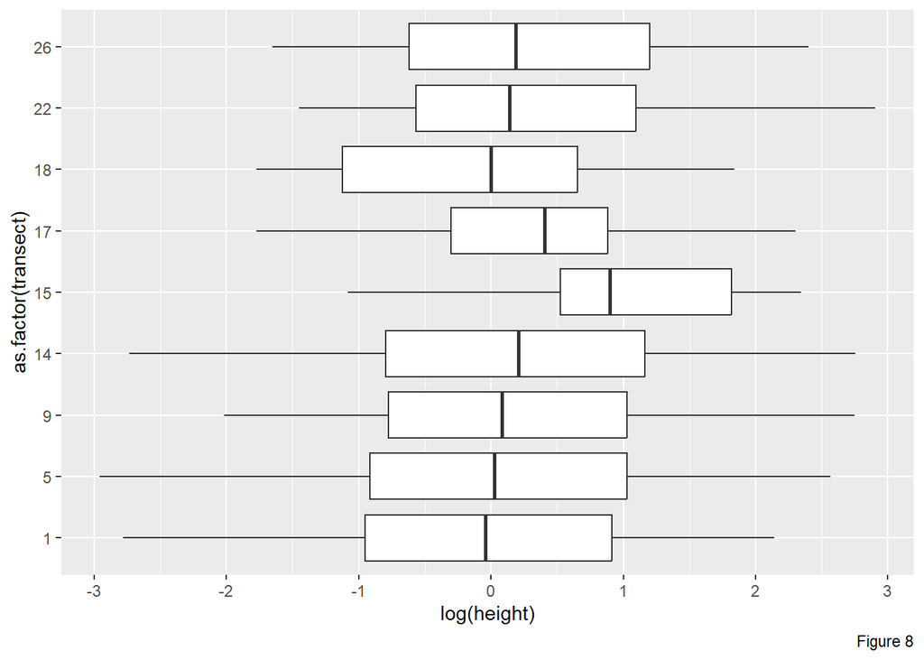

```r
ggplot(treeTubes) +
  geom_boxplot(aes(x = as.factor(transect), y=log(height))) +
  coord_flip()+
  labs(caption = "Figure 8")
```

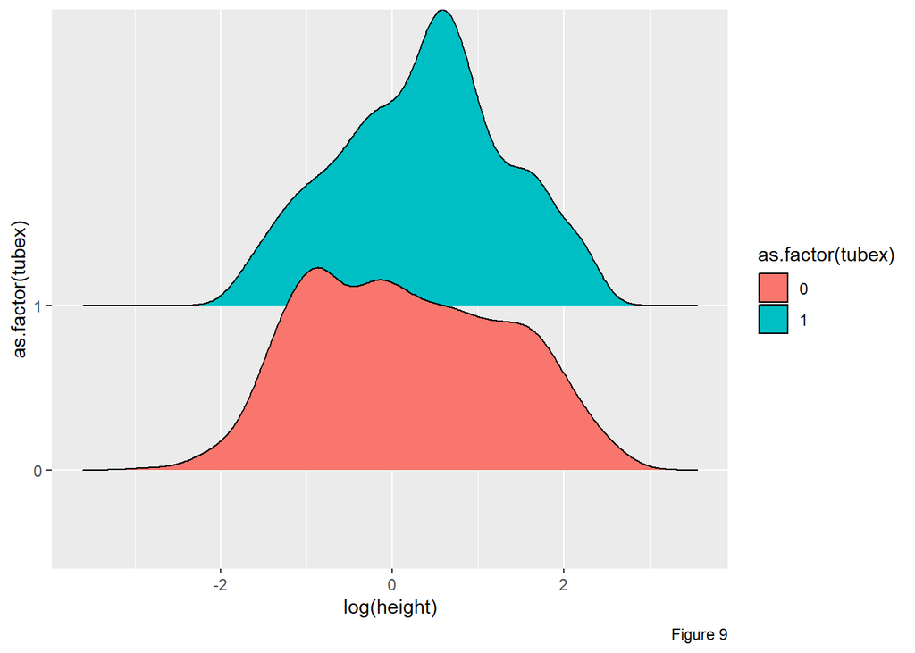

```r
ggplot(treeTubes) +
  geom_density_ridges(aes(x = log(height), y = as.factor(tubex), fill = as.factor(tubex)))+
  labs(caption = "Figure 9")
```

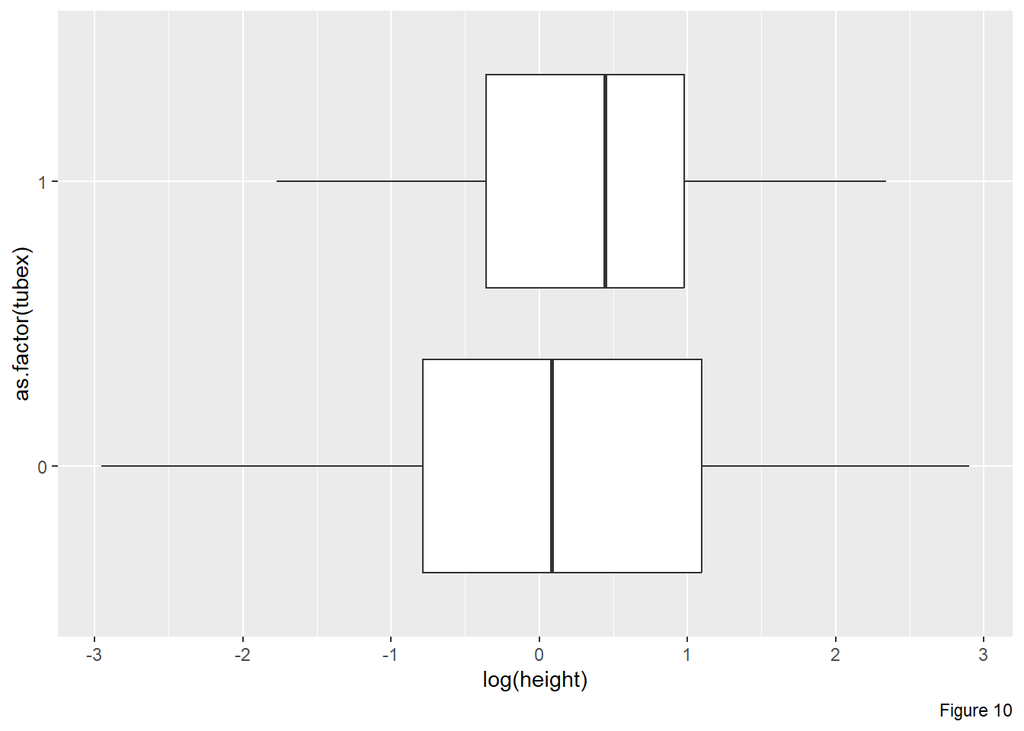

```r
ggplot(treeTubes) +
  geom_boxplot(aes(x = as.factor(tubex), y = log(height))) +
  coord_flip()+
  labs(caption = "Figure 10")
```

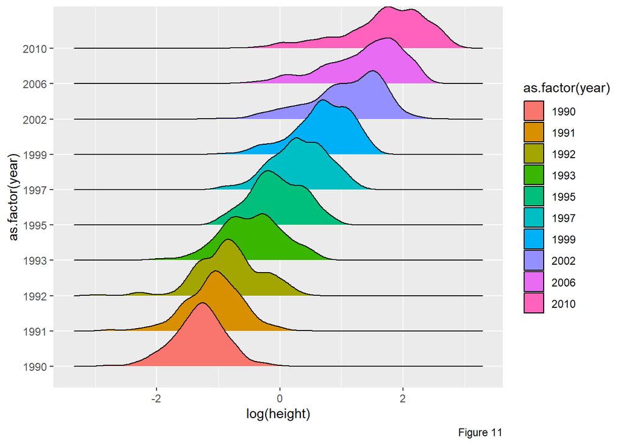

```r
ggplot(treeTubes) +
  geom_density_ridges(aes(x = log(height), y = as.factor(year),fill = as.factor(year)))+
  labs(caption = "Figure 11")
```

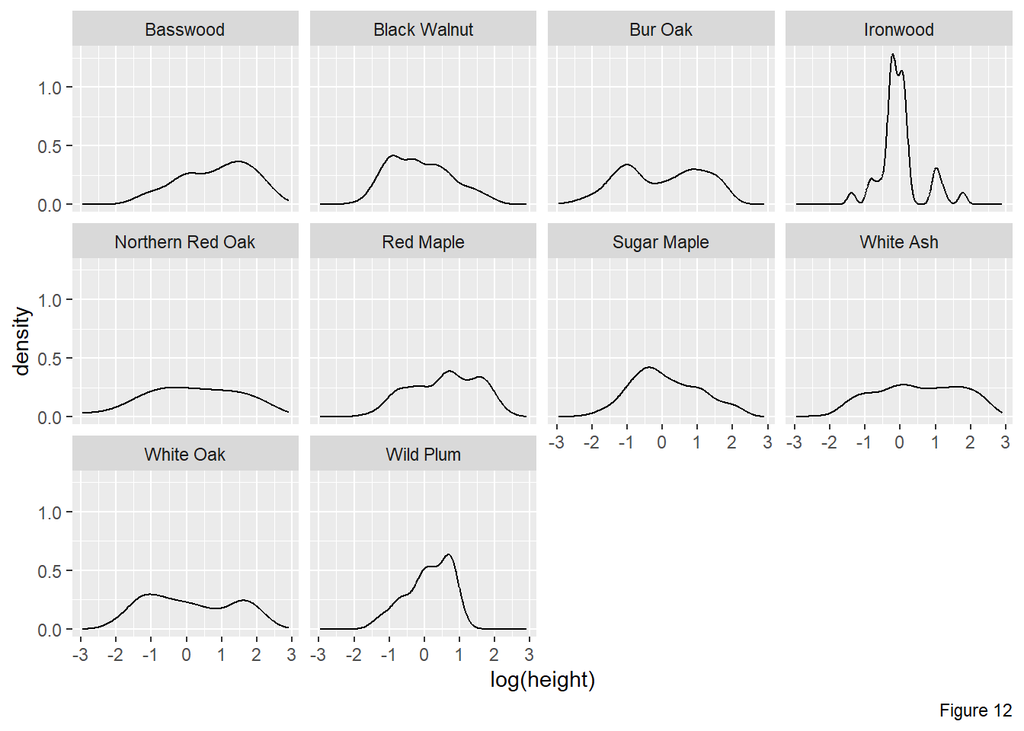

```r
ggplot(treeTubes) +
  geom_density(aes(x = log(height))) +
  facet_wrap(~species)+
  labs(caption = "Figure 12")
```

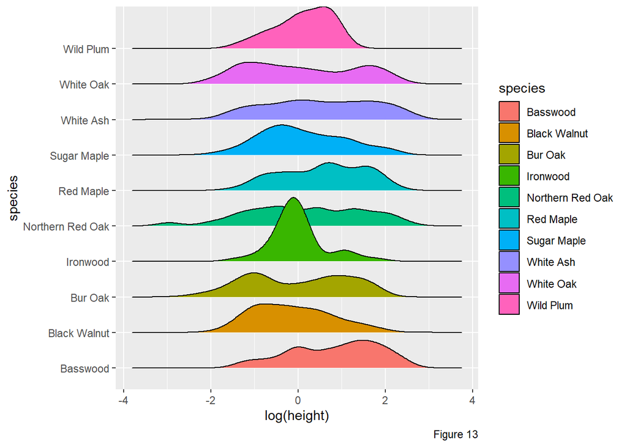

```r
ggplot(treeTubes) +
  geom_density_ridges(aes(x = log(height), y = species,fill=species))+
  labs(caption = "Figure 13")
```

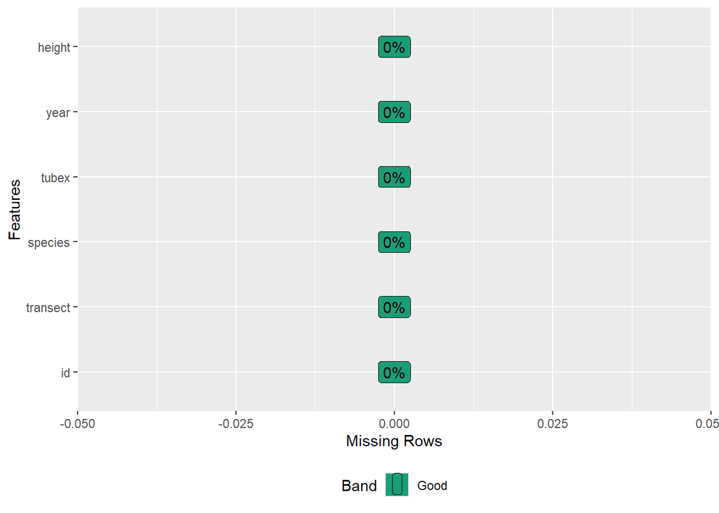

```r
plot_missing(treeTubes)
```

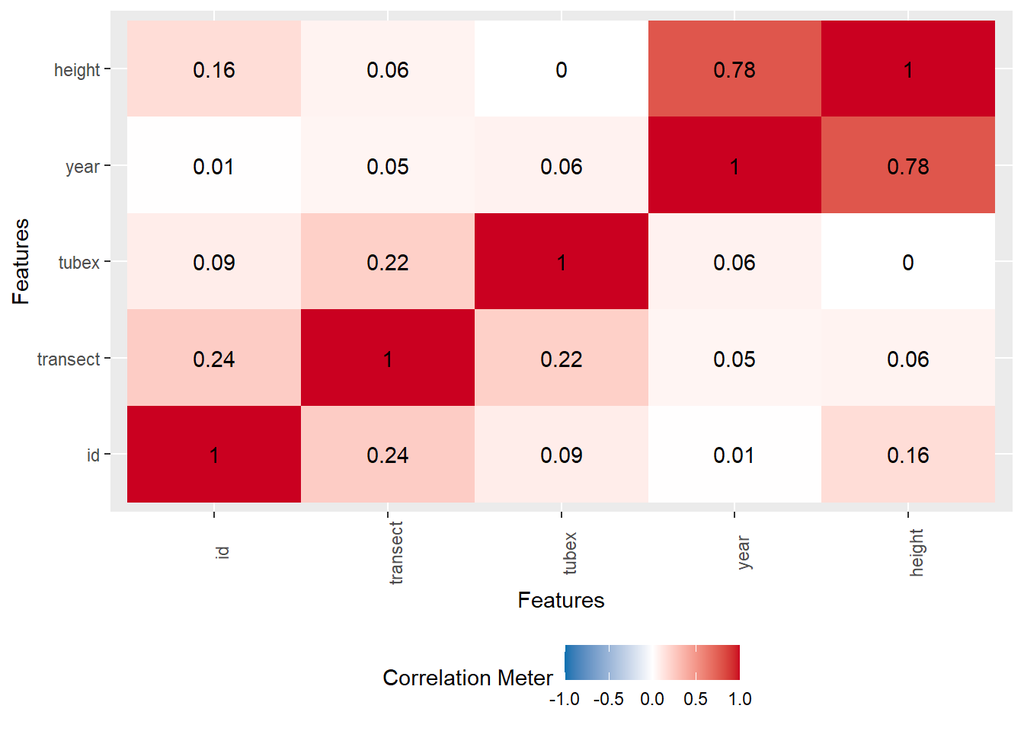

```r
plot_correlation(treeTubes,type = "continuous")
```